# Tuberculose

Trabalho de Graduação (2019-2021)

ZDB: utilizando banco de dados para gerenciamento, análise e conscientização sobre zoonoses no Brasil

Discente: Liandra Ayumi Federizi Yoshida

Orientadora: Fernanda Nascimento Almeida

### Saiba mais sobre a doença e os números no país:

[video not shown]

Mais informações do Ministério da Saúde: [Tuberculose: o que é, causas, sintomas, tratamento, diagnóstico e prevenção](http://www.saude.gov.br/saude-de-a-z/tuberculose)

### Baixe o arquivo de dados:

[Download](https://docs.google.com/uc?export=download&id=1oQ6_AXp0xZ2t6YnEzGOoDXOShWXhRkjX)

### Estatísticas descritivas em linguagem R:

```r
#limpa dados
rm(list = ls())

# definir diretório
setwd("insira o diretorio em que seu arquivo foi armazenado")

# verificar diretório
getwd()
```

```
## [1] "diretorio"
```

```r
# carrega pacote de manipulação de tabelas
if (!require("data.table")){
  install.packages("data.table")
}
library("data.table")

#carrega dados
tabela <- read.csv("tabela.csv",sep=";")

#monta tabela com dados de tuberculose apenas
ocor = tabela$ocorrencia[tabela$cod_zoo==15] #ocorrencias
an = tabela$ano[tabela$cod_zoo==15] #ano
re = tabela$cod_regiao[tabela$cod_zoo==15] #regiao
escola = tabela$escolaridade[tabela$cod_zoo==15] #escolaridade
munextr = tabela$mun_extr_pobreza[tabela$cod_zoo==15] #municipio de extrema pobreza
idade = tabela$classif_etaria[tabela$cod_zoo==15] #idade
gen = tabela$sexo[tabela$cod_zoo==15] #genero
evol = tabela$evolucao[tabela$cod_zoo==15] #evolução do caso
desp <- data.table(an,ocor,re,escola,munextr,idade,gen,evol) #tabela com dados específicos de tuberculose
```

### Ocorrências totais ao longo dos anos:

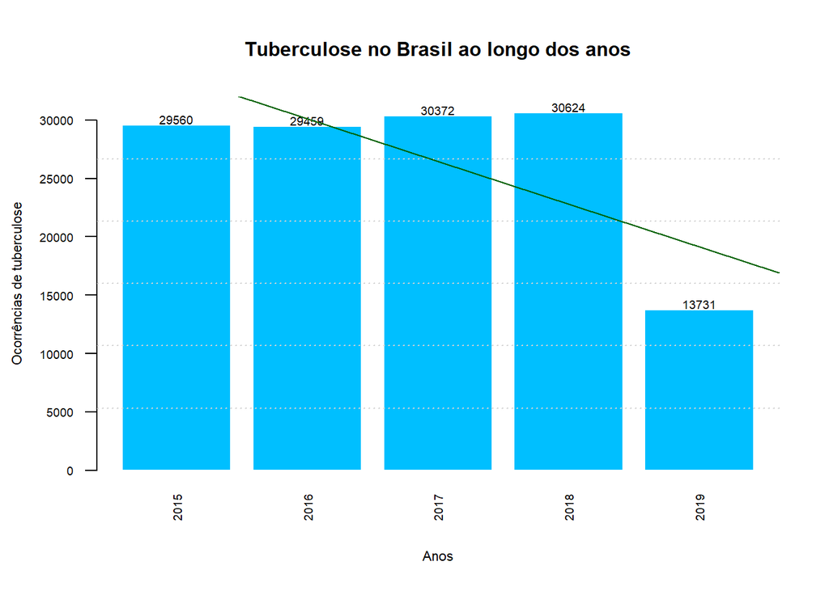

```r
graf = tapply(desp$ocor,desp$an,sum)
bp <- barplot(graf, border = F, las=2, ylim = c(0,32000), xlab = "Anos", ylab = "Ocorrências de tuberculose", main = "Tuberculose no Brasil ao longo dos anos", col = "DeepSkyBlue", cex.names = 0.6, cex.axis = 0.6, cex.main = 1.0, cex.lab = 0.7) #gráfico de barras
text(x=as.vector(bp), y=graf+1, labels = graf, pos=3, offset = 0.05, cex = 0.6)
grid(ny = 6, nx = NA) #linhas de grade
abline(lsfit(1:length(graf),graf), col = "darkgreen") #linha de tendência
```

A tuberculose é uma das zoonoses com maior quantidade e detalhamento de dados no sistema do DATASUS. De 2015 a 2018 o número de casos manteve-se em um mesmo patamar, havendo redução em 2019. Esta pode ser decorrente tanto de ações de prevenção quanto da ausência de dados totais disponíveis até o momento. A última atualização em massa do DATASUS ocorreu em Março de 2020, sendo que em nota ressalta-se que os dados ainda precisam de revisão.

### Ocorrências totais por região:

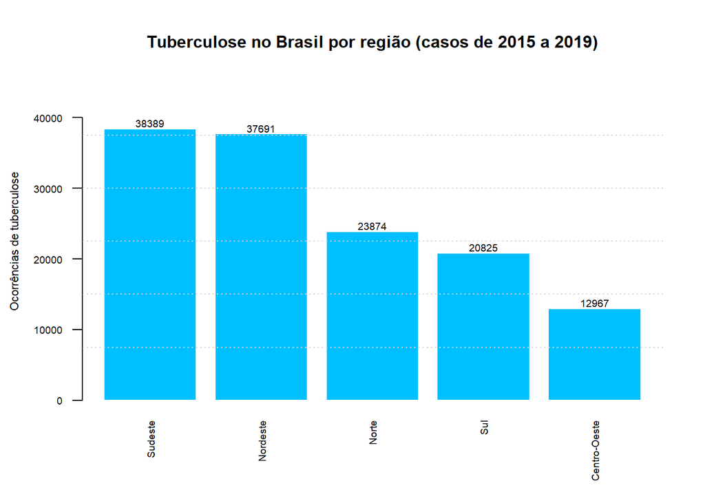

```r
aux = tapply(desp$ocor,desp$re,sum)
names(aux) = c("Norte","Nordeste","Sudeste","Sul","Centro-Oeste")
aux = sort(aux, decreasing = TRUE)
bp <- barplot(aux, border = F, ylim = c(0,45000), las=2, names.arg = names(aux), ylab = "Ocorrências de tuberculose", main = "Tuberculose no Brasil por região (casos de 2015 a 2019)", col = "DeepSkyBlue", cex.names = 0.6, cex.axis = 0.6, cex.main = 1.0, cex.lab = 0.7)
text(x=as.vector(bp), y=aux+1, labels = aux, pos=3, offset = 0.1, cex = 0.6)
grid(ny = 6, nx = NA)
```

### Por escolaridade:

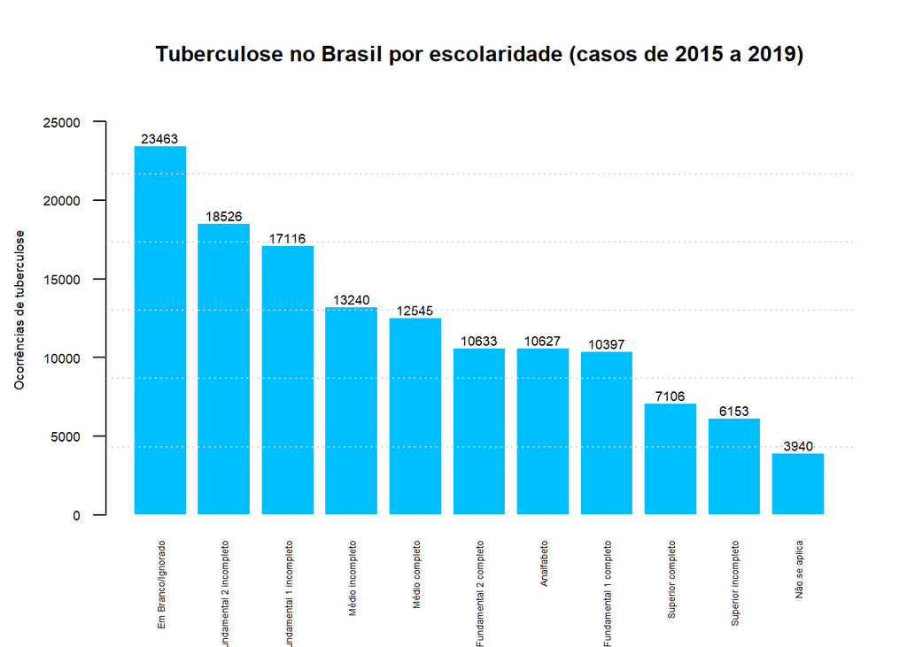

```r
grafesc = tapply(desp$ocor,desp$escola,sum)
grafesc = sort(grafesc, decreasing = TRUE)
bp <- barplot(grafesc, border = F, ylim = c(0,26000), las=2, ylab = "Ocorrências de tuberculose", main = "Tuberculose no Brasil por escolaridade (casos de 2015 a 2019)", col = "DeepSkyBlue", cex.names = 0.45, cex.axis = 0.6, cex.main = 1.0, cex.lab = 0.6)
text(x=as.vector(bp), y=grafesc+1, labels = grafesc, pos=3, offset = 0.1, cex = 0.6)
grid(ny = 6, nx = NA)
```

Há uma presença muito elevada de dados não preenchidos nas fichas de notificação. Estes aparecem como “Em branco/Ignorado” e analisando em termos de escolaridade dos casos, este fator torna mais difícil a elaboração de estratégias adequadas de prevenção.

### Por município de extrema pobreza:

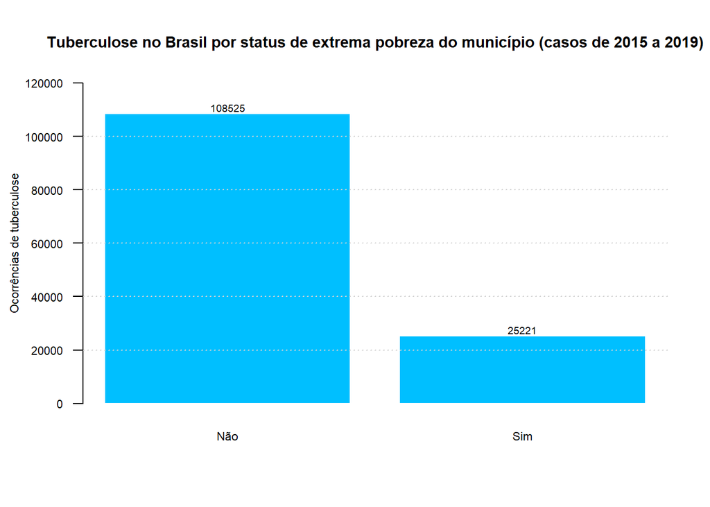

```r
grafmep = tapply(desp$ocor,desp$munextr,sum)
names(grafmep) = c("Não","Sim")
grafmep = sort(grafmep, decreasing = TRUE)
bp <- barplot(grafmep, border = F, ylim = c(0,120000), las=1, ylab = "Ocorrências de tuberculose", main = "Tuberculose no Brasil por status de extrema pobreza do município (casos de 2015 a 2019)", col = "DeepSkyBlue", cex.names = 0.7, cex.axis = 0.7, cex.main = 0.9, cex.lab = 0.7)
text(x=as.vector(bp), y=grafmep+1, labels = grafmep, pos=3, offset = 0.1, cex = 0.6)
grid(ny = 6, nx = NA)
```

### Por classificação etária:

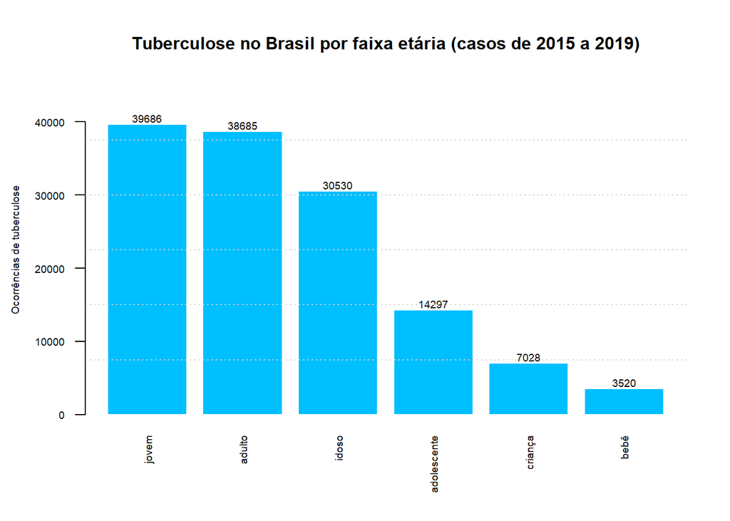

```r
grafidade = tapply(desp$ocor,desp$idade,sum)
grafidade = sort(grafidade, decreasing = TRUE)
bp <- barplot(grafidade, border = F, ylim = c(0,45000), las=2, ylab = "Ocorrências de tuberculose", main = "Tuberculose no Brasil por faixa etária (casos de 2015 a 2019)", col = "DeepSkyBlue", cex.names = 0.6, cex.axis = 0.6, cex.main = 1.0, cex.lab = 0.6)
text(x=as.vector(bp), y=grafidade+1, labels = grafidade, pos=3, offset = 0.1, cex = 0.6)
grid(ny = 6, nx = NA)
```

```r
#tabela com as faixas de idade de cada classificação:
faixas <- data.table(categoria = c("bebês", "crianças",
                            "adolescentes", "jovens",                                     "adultos", "idosos"),
                   idade = c("0-4 anos", "5-14 anos", "15-19 anos", "20-39 anos", "40-59 anos", "a partir de 60 anos"))
faixas
```

```
##       categoria               idade
## 1:        bebês            0-4 anos
## 2:     crianças           5-14 anos
## 3: adolescentes          15-19 anos
## 4:       jovens          20-39 anos
## 5:      adultos          40-59 anos
## 6:       idosos a partir de 60 anos
```

### Por gênero:

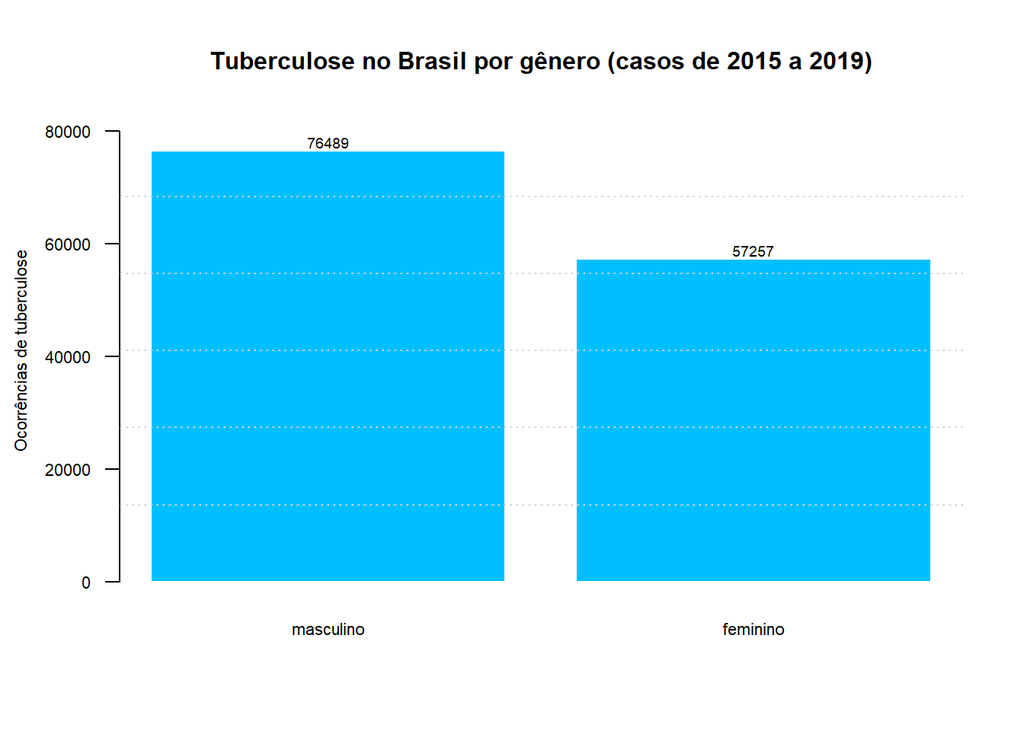

```r
grafgen = tapply(desp$ocor,desp$gen,sum)
grafgen = sort(grafgen, decreasing = TRUE)
bp <- barplot(grafgen, border = F, ylim = c(0,82000), las=1, ylab = "Ocorrências de tuberculose", main = "Tuberculose no Brasil por gênero (casos de 2015 a 2019)", col = "DeepSkyBlue", cex.names = 0.7, cex.axis = 0.7, cex.main = 1.0, cex.lab = 0.7)
text(x=as.vector(bp), y=grafgen+1, labels = grafgen, pos=3, offset = 0.1, cex = 0.6)
grid(ny = 6, nx = NA)
```

### Por evolução do caso:

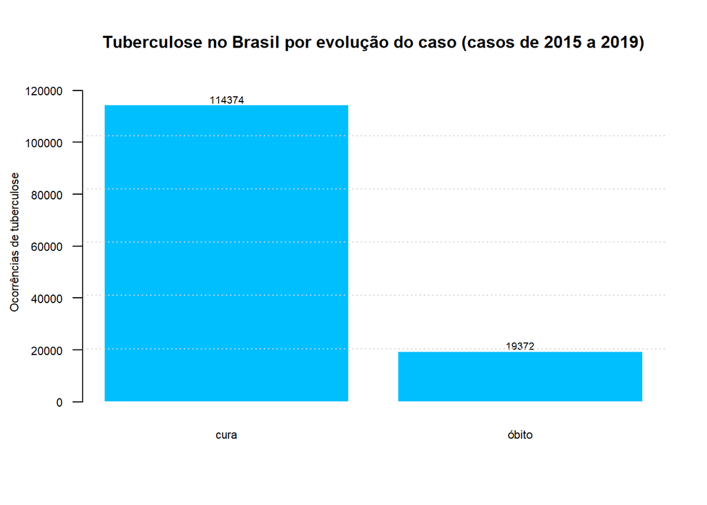

```r
grafevol = tapply(desp$ocor,desp$evol,sum)
names(grafevol) = c("cura","óbito")
grafevol = sort(grafevol, decreasing = TRUE)
bp <- barplot(grafevol, border = F, ylim = c(0,123000), las=1, ylab = "Ocorrências de tuberculose", main = "Tuberculose no Brasil por evolução do caso (casos de 2015 a 2019)", col = "DeepSkyBlue", cex.names = 0.7, cex.axis = 0.7, cex.main = 1.0, cex.lab = 0.7)
text(x=as.vector(bp), y=grafevol+1, labels = grafevol, pos=3, offset = 0.1, cex = 0.6)
grid(ny = 6, nx = NA)
```

Para dúvidas ou mais informações entrar em contato através do endereço de email:

zdb.zoonosisdatabase@gmail.com

##### **Suporte:**

[figure not shown]

© Zoonosis DataBase | *zdb.zoonosisdatabase@gmail.com*